# R for Data Analysis

Data Science Melbourne - MeDaScIn 2018

Kaushik Lakshman

27 September 2018

# Before we start

## A bit about me

- Kaushik Lakshman, Data Scientist at Betfair
- R user since ~2013 & massive R fan since day 1
- Hoping to infect you with the same passion!
- No such thing as a stupid question. Interrupt me whenever you have any question
- Everyone is here to learn, don’t want anyone feeling left behind :)
- If you have any questions for later, don’t hesitate to email me kaushiklakshman@gmail.com

## What we will cover today

- An introduction to R & its ecosystem
- Data manipulation/wrangling/munging using dplyr
- Data visualisation using ggplot2
- Rmarkdown and related tools

# Introduction to R

## What is R?

- R is a programming language originally meant for Statistical Computing
- R is now so much more than that
- R is about 25 years old, but has really exploded in the last 5 years
  - Open source and free
  - Incredible dev community (a package for everything)
  - Barrier to entry reduced

## What can you do in R?

- Access data from a variety of systems (files, databases, streams)
- Manipulate data (and fix or create data)
- Visualise data
- Model data
- Report data (Commentary, insights, visualisations, summaries)
- A host of other modern tools
  - Web applications
  - Dashboards
  - Packages
  - Emoji!
  - Music!
  - Emails!

## Why is R popular these days?

- Incredible community around R programming and especially R learning
- R Studio’s packages and approach to making analysis easy
- Help and Documentation
- Stack overflow & Rstudio community
- Twitter, Linkedin and social media

## RStudio

- RStudio is the defacto IDE for R Programming
- Free to download and has very well thought out ease of use features
  - Code, Console, Environment and Plots/Help on the same window
  - Auto complete code and auto formatting
  - Tons of little features to customise according to your liking
- Has the brightest minds in data science working towards making it easier for other data scientists : Hadley Wickham, Jim Hester, Max Kuhn, Mine Cetinkaya Rundel, Yihui Xie, JJ Alaire

## Basic Syntax

- Mathematical expressions are evaluated as a calculator

```r
3+3
```

```
## [1] 6
```

- You can assign values to variables using the assignment operator `<-`

```r
quick_maths <- 2 + 2 - 1
```

- You can print values by just typing their name of the variable

```r
quick_maths
```

```
## [1] 3
```

## Functions

- Functions take in values and return something
- Functions are meant to be consistent - Same output for same inputs
- R provides several built in functions

```r
sum(1,2,3) ## Adding 1, 2 and 3
```

```
## [1] 6
```

```r
sqrt(25) ## Finding square root of 25
```

```
## [1] 5
```

## Packages

- Inbuilt functions only cover a subset of what one needs to do on a day to day basis
- Packages exist to service this need
- Packages are maintained in a centralised repository called CRAN
- Packages can also be obtained from other sources
- Packages are installed using the function `install.packages("package_name")`
- Installed packages are loaded to your environment using `library(package_name)`

## Packages

- Let us try install a very useful package called lubridate
- Lubridate makes it easier to work with dates and times

```r
install.packages("lubridate")
```

```r
library(lubridate)

## ymd converts a date in the format YYYY-MM-DD to a date class
an_example_date <- lubridate::ymd("2018-09-27")
class(an_example_date)
```

```
## [1] "Date"
```

```r
## Adding 5 days to an_example_date
an_example_date + lubridate::days(5)
```

```
## [1] "2018-10-02"
```

## Basic Data Types

- Everything in R is an object
- Main atomic data types are: charcter, numeric, logical
- Use the class function to find out what data type your object is

```r
name <- "Kaushik" ## Character
age <- 29 ## Numeric
```

```r
class(name)
```

```
## [1] "character"
```

```r
class(age)
```

```
## [1] "numeric"
```

## Basic Data Types

- Collection of these atomic structures are called vectors
- You can create vectors using the function `c()`

```r
cities_in_australia <- c("Melbourne", "Sydney", "Brisbane") ## Vector of Chars
ten_natural_numbers <- c(1:10) ## Vector of numerics
```

```r
cities_in_australia
```

```
## [1] "Melbourne" "Sydney"    "Brisbane"
```

```r
ten_natural_numbers
```

```
##  [1]  1  2  3  4  5  6  7  8  9 10
```

## Data Frames

- Most important data structure in R
- Combination of Vectors
- Rectangular structure (most data in the world)
- Has Rows and Columns
- R has some pre loaded data frames to play around with what they look like

## Data Frames

```r
## Creating your own data frame
my_first_data_frame <-
data.frame(city = c("Melbourne","Sydney","Canberra"),
           is_capital = c(FALSE,FALSE,TRUE))
```

```r
my_first_data_frame
```

```
##        city is_capital
## 1 Melbourne      FALSE
## 2    Sydney      FALSE
## 3  Canberra       TRUE
```

```r
class(my_first_data_frame)
```

```
## [1] "data.frame"
```

## Data Frames

```r
## Pre loaded data frame
data(mtcars)
```

```r
## Use the head function to sample a subset of rows
## because most data frames will be too long to print everything
head(mtcars, 3)
```

```
##                mpg cyl disp  hp drat    wt  qsec vs am gear carb
## Mazda RX4     21.0   6  160 110 3.90 2.620 16.46  0  1    4    4
## Mazda RX4 Wag 21.0   6  160 110 3.90 2.875 17.02  0  1    4    4
## Datsun 710    22.8   4  108  93 3.85 2.320 18.61  1  1    4    1
```

```r
## Use str to inspect the data frame at a glance
str(mtcars)
```

```
## 'data.frame':    32 obs. of  11 variables:
##  $ mpg : num  21 21 22.8 21.4 18.7 18.1 14.3 24.4 22.8 19.2 ...
##  $ cyl : num  6 6 4 6 8 6 8 4 4 6 ...
##  $ disp: num  160 160 108 258 360 ...
##  $ hp  : num  110 110 93 110 175 105 245 62 95 123 ...
##  $ drat: num  3.9 3.9 3.85 3.08 3.15 2.76 3.21 3.69 3.92 3.92 ...
##  $ wt  : num  2.62 2.88 2.32 3.21 3.44 ...
##  $ qsec: num  16.5 17 18.6 19.4 17 ...
##  $ vs  : num  0 0 1 1 0 1 0 1 1 1 ...
##  $ am  : num  1 1 1 0 0 0 0 0 0 0 ...
##  $ gear: num  4 4 4 3 3 3 3 4 4 4 ...
##  $ carb: num  4 4 1 1 2 1 4 2 2 4 ...
```

## Getting data in and out of R

- Data can be available in several formats for analysis
  - Files
  - Databases
  - APIs
- We can use the appropriate packages to load data from any system to R
- Today we will be working only with CSV files, for which we will need the `read_csv` and `write_csv` functions
- These are available through an incredible `tidyverse` package that we will learn about

```r
install.packages("tidyverse")
```

## Getting data in and out of R

```r
## Loading package tidyverse
library(tidyverse)

## Loading Melbourne Housing Dataset
melbourne_housing <- read_csv("C:/Workspace/r-learning/data/processed/melbourne_housing_market.csv")

glimpse(melbourne_housing)
```

```
## Observations: 56,737
## Variables: 8
## $ suburb        <chr> "Abbotsford", "Abbotsford", "Abbotsford", "Aberf...
## $ address       <chr> "49 Lithgow St", "59A Turner St", "119B Yarra St...
## $ rooms         <int> 3, 3, 3, 3, 2, 2, 2, 3, 6, 3, 3, 4, 2, 4, 2, 4, ...
## $ type          <chr> "h", "h", "h", "h", "h", "t", "u", "h", "h", "h"...
## $ price         <int> 1490000, 1220000, 1420000, 1515000, 670000, 5300...
## $ method        <chr> "S", "S", "S", "S", "S", "S", "S", "SP", "PI", "...
## $ selling_agent <chr> "Jellis", "Marshall", "Nelson", "Barry", "Nelson...
## $ dt            <chr> "1/04/2017", "1/04/2017", "1/04/2017", "1/04/201...
```

## Getting data in and out of R

```r
## Getting data from Excel to R
data_from_excel <- readxl::read_xlsx(path = "My_file.xlsx",
                                     sheet = "Main Sheet")

## Loading R data structure
data_from_rds <- readRDS(file = "saved_object.RDS")

## Getting data from database
library(odbc)
mysql_connection <- odbc::dbConnect(odbc(),
                                    Driver = "SQL Server",
                                    Server = "localhost\\SQLEXPRESS",
                                    Database = "datawarehouse",
                                    Trusted_Connection = "True")

my_table_data <- odbc::dbGetQuery(conn = mysql_connection,
                                  statement = "SELECT * FROM my_table")
```

## Introduction to Tidyverse

- Tidyverse is a collection of packages
- The packages share an underlying design philosophy, grammar of usage and data structures
- The tidy data principles state that
  - Each variable is a column
  - Each observation is a row
  - Each type of observational unit forms a table

```r
## The dataset we loaded is tidy
head(melbourne_housing, 3)
```

```
## # A tibble: 3 x 8
##   suburb     address       rooms type    price method selling_agent dt
##   <chr>      <chr>         <int> <chr>   <int> <chr>  <chr>         <chr>
## 1 Abbotsford 49 Lithgow St     3 h     1490000 S      Jellis        1/04/~
## 2 Abbotsford 59A Turner St     3 h     1220000 S      Marshall      1/04/~
## 3 Abbotsford 119B Yarra St     3 h     1420000 S      Nelson        1/04/~
```

# Data Wrangling with dplyr

## What is dplyr?

- Data manipulation is really easy and intuitive now because of the `dplyr` package (Contained in `tidyverse`)
- You can use other techniques that base R and other packages provide to do the same stuff but with `dplyr` you don’t need to know that anymore!
- `dplyr` is the next evolution of the `plyr` package specifically tuned for data frames and having easy and consistent data wrangling features

## Piping

- Piping comes from a package called `magrittr`
- Piping allows you to chain consecutive steps of a data manipulation pipeline
- In order of how it is executed as opposed to traditional programming syntax
- Piping is really useful while building dplyr command chains

```r
## Non Piping
output <- function3(function2(function1(x)))

## Piping
output <- x %>%
  function1() %>%
  function2() %>%
  function3
```

## Select

- Select lets you keep only a subset of variables from a data frame

```r
melbourne_housing %>%
  select(address, suburb)
```

```
## # A tibble: 56,737 x 2
##    address           suburb
##    <chr>             <chr>
##  1 49 Lithgow St     Abbotsford
##  2 59A Turner St     Abbotsford
##  3 119B Yarra St     Abbotsford
##  4 68 Vida St        Aberfeldie
##  5 92 Clydesdale Rd  Airport West
##  6 4/32 Earl St      Airport West
##  7 3/74 Hawker St    Airport West
##  8 1/26 Highridge Cr Airport West
##  9 1 Jackson Cct     Albanvale
## 10 18 Mills St       Albert Park
## # ... with 56,727 more rows
```

## Filter

- Filter lets you keep only a subset of observations that satisy a condition

```r
melbourne_housing %>%
  filter(suburb == "Southbank")
```

```
## # A tibble: 97 x 8
##    suburb    address        rooms type   price method selling_agent dt
##    <chr>     <chr>          <int> <chr>  <int> <chr>  <chr>         <chr>
##  1 Southbank 1902/63 White~     2 u     630000 SP     MICM          1/04/~
##  2 Southbank 173/38 Kavana~     2 u     512000 S      MICM          2/06/~
##  3 Southbank 191/173 City ~     3 u     801000 S      MICM          3/02/~
##  4 Southbank 58/88 Southba~     2 u     530000 S      MICM          3/02/~
##  5 Southbank 3/106 Southba~     2 u     717000 S      RT            3/03/~
##  6 Southbank 801/151 City ~     3 u     765000 S      MICM          3/06/~
##  7 Southbank 512/22 Dorcas~     1 u     422000 S      MICM          3/06/~
##  8 Southbank 83/88 Kavanag~     2 u         NA PI     Lucas         3/06/~
##  9 Southbank 2605/63 White~     2 u     590000 PI     MICM          3/06/~
## 10 Southbank 41/106 Southb~     3 u     720000 S      VICPROP       3/09/~
## # ... with 87 more rows
```

## Filter

- You can use any logical operators `>`, `<`, `==`, `!=`
- You can combine multiple logical operators using `&` and `|`

```r
melbourne_housing %>%
  filter(suburb == "Mount Waverley" & rooms >= 3 & price <= 1000000)
```

```
## # A tibble: 109 x 8
##    suburb         address    rooms type   price method selling_agent dt
##    <chr>          <chr>      <int> <chr>  <int> <chr>  <chr>         <chr>
##  1 Mount Waverley 44 Smyth ~     4 h     980000 SP     Barry         1/04~
##  2 Mount Waverley 11 Mauree~     3 h     944000 S      Jellis        1/07~
##  3 Mount Waverley 3/24 Adri~     3 t     592000 S      McGrath       2/06~
##  4 Mount Waverley 2/18 Leon~     3 h     855000 S      McGrath       3/06~
##  5 Mount Waverley 1/7 Headi~     3 t     975000 S      Buxton        3/09~
##  6 Mount Waverley 20 Sampso~     3 h     967000 SP     Barry         3/09~
##  7 Mount Waverley 25 Tuhans~     3 h     976000 S      Ray           3/12~
##  8 Mount Waverley 2/34 Brig~     3 t     800000 S      Buxton        4/03~
##  9 Mount Waverley 2/47 Doyn~     3 h     950000 PI     hockingstuart 4/03~
## 10 Mount Waverley 14/38 Sam~     3 t     835000 S      hockingstuart 4/03~
## # ... with 99 more rows
```

## Arrange

- Arrange lets you sort your data frame by any column you specify
- Defaut order is ascending but we can use `desc()` to sort in descending order

```r
melbourne_housing %>%
  filter(suburb == "Mount Waverley" & rooms >= 3 & price <= 1000000) %>%
  arrange(desc(rooms), price)
```

```
## # A tibble: 109 x 8
##    suburb         address   rooms type   price method selling_agent dt
##    <chr>          <chr>     <int> <chr>  <int> <chr>  <chr>         <chr>
##  1 Mount Waverley 460 Wave~     6 h     941000 S      Barry         27/06~
##  2 Mount Waverley 69 Bruce~     5 h     855000 PI     Jellis        17/03~
##  3 Mount Waverley 6 Meliss~     5 h     927000 S      McGrath       28/05~
##  4 Mount Waverley 1/51 Wil~     4 u     775000 PI     Barry         10/12~
##  5 Mount Waverley 1/25 Sad~     4 t     803000 S      McGrath       16/06~
##  6 Mount Waverley 1/30 Sad~     4 t     830000 S      Barry         6/08/~
##  7 Mount Waverley 1/42 Bri~     4 u     850000 S      Barry         28/05~
##  8 Mount Waverley 21 Rolan~     4 h     940000 S      Barry         17/02~
##  9 Mount Waverley 81 There~     4 h     950000 VB     Stockdale     14/04~
## 10 Mount Waverley 489 Wave~     4 h     950000 S      Barry         16/04~
## # ... with 99 more rows
```

## Rename

- Rename lets you rename your columns to anything you want

```r
melbourne_housing %>%
  select(address, suburb) %>%
  rename(suburb_name = suburb)
```

```
## # A tibble: 56,737 x 2
##    address           suburb_name
##    <chr>             <chr>
##  1 49 Lithgow St     Abbotsford
##  2 59A Turner St     Abbotsford
##  3 119B Yarra St     Abbotsford
##  4 68 Vida St        Aberfeldie
##  5 92 Clydesdale Rd  Airport West
##  6 4/32 Earl St      Airport West
##  7 3/74 Hawker St    Airport West
##  8 1/26 Highridge Cr Airport West
##  9 1 Jackson Cct     Albanvale
## 10 18 Mills St       Albert Park
## # ... with 56,727 more rows
```

## Mutate

- Mutate lets you create new columns or variables

```r
melbourne_housing %>%
  filter(suburb == "Toorak" & price >= 1000000) %>%
  select(address, suburb, price) %>%
  mutate(price_in_millions = price/1000000)
```

```
## # A tibble: 118 x 4
##    address           suburb   price price_in_millions
##    <chr>             <chr>    <int>             <dbl>
##  1 1/62 Mathoura Rd  Toorak 1850000              1.85
##  2 5/568 Toorak Rd   Toorak 1600000              1.60
##  3 113 Grange Rd     Toorak 2800000              2.80
##  4 5 Theodore Ct     Toorak 4000000              4.00
##  5 3/24 Lascelles Av Toorak 1800000              1.80
##  6 3/14 Martin Ct    Toorak 2000000              2.00
##  7 9 Devorgilla Av   Toorak 4300000              4.30
##  8 1/3 Glover Ct     Toorak 1435000              1.44
##  9 10 Myoora Rd      Toorak 5500000              5.50
## 10 232 Williams Rd   Toorak 1635000              1.64
## # ... with 108 more rows
```

## Basic functions wrap up

- Select: Choose columns you want
- Filter: Choose rows that you want based on conditions
- Arrange: Sort based on any column(s)
- Rename: Change names of existing columns
- Mutate: Create new columns
- Quick practice: Can you write a dplyr chain to give me all the addresses, suburbs and prices for those properties that were townhouses (type is ‘t’) and sold for more than 1.2 million sorted by descending order of price?

## Basic functions Quick practice - Answer

```r
melbourne_housing %>%
  filter(type == 't' & price > 1200000) %>%
  select(address, suburb, price) %>%
  arrange(desc(price))
```

```
## # A tibble: 843 x 3
##    address          suburb        price
##    <chr>            <chr>         <int>
##  1 10A Dawson Av    Brighton    3820000
##  2 65 Caroline St   South Yarra 3475000
##  3 10A Hartley St   Brighton    3275000
##  4 1/19 Wallace Av  Toorak      3155000
##  5 7/202 Nepean Hwy Aspendale   3125000
##  6 81 Carpenter St  Brighton    2900000
##  7 82A Were St      Brighton    2900000
##  8 25 Lindsay St    Brighton    2800000
##  9 32 Milton Pde    Malvern     2750000
## 10 11 Church St     Toorak      2700000
## # ... with 833 more rows
```

## Group & Summarise

- Data analysis is usually done on rolled up groups
- Collect multiple rows into a set and study summarised statistics for them
- `dplyr` provides the `group_by` function to let you do this
- Once grouped, we can use the `summarise` function to reduce multiple values to one value

```r
melbourne_housing %>%
  group_by(suburb) %>%
  summarise(mean_price = mean(price, na.rm = TRUE))
```

```
## # A tibble: 385 x 2
##    suburb         mean_price
##    <chr>               <dbl>
##  1 Abbotsford       1046322.
##  2 Aberfeldie       1304669.
##  3 Airport West      766103.
##  4 Albanvale         504050.
##  5 Albert Park      1948920.
##  6 Albion            617753.
##  7 Alphington       1410197.
##  8 Altona            889231.
##  9 Altona Meadows    630024.
## 10 Altona North      791006.
## # ... with 375 more rows
```

## Summarise

- Summarise function gives you a bunch of options
  - `n()` counting rows
  - `n_distinct()` counting unique rows
  - `sum()` summing a variable
  - `mean()` average of a variable
  - `median()` median of a variable
  - and several more

```r
## Counting number of houses that sold
## for > 2 million in Brighton and Toorak
melbourne_housing %>%
  filter(suburb == "Toorak" | suburb == "Brighton") %>%
  filter(price > 2000000) %>%
  group_by(suburb) %>%
  summarise(number_of_houses = n())
```

```
## # A tibble: 2 x 2
##   suburb   number_of_houses
##   <chr>               <int>
## 1 Brighton              157
## 2 Toorak                 62
```

## Another quick practice session

- Out of all the units that were sold
- give me a list of suburbs
- that sold units of price > 1m
- and how many of such units each suburb had
- Expected answer below

```
## # A tibble: 86 x 2
##    suburb       number_of_units
##    <chr>                  <int>
##  1 Abbotsford                 5
##  2 Aberfeldie                 1
##  3 Albert Park                2
##  4 Altona                     5
##  5 Armadale                   5
##  6 Ashburton                  2
##  7 Ashwood                    2
##  8 Balwyn                    14
##  9 Balwyn North              15
## 10 Beaumaris                  2
## # ... with 76 more rows
```

## Another quick practice session - Solution

```r
melbourne_housing %>%
  filter(type == "u") %>%
  filter(price > 1000000) %>%
  group_by(suburb) %>%
  summarise(number_of_units = n())
```

```
## # A tibble: 86 x 2
##    suburb       number_of_units
##    <chr>                  <int>
##  1 Abbotsford                 5
##  2 Aberfeldie                 1
##  3 Albert Park                2
##  4 Altona                     5
##  5 Armadale                   5
##  6 Ashburton                  2
##  7 Ashwood                    2
##  8 Balwyn                    14
##  9 Balwyn North              15
## 10 Beaumaris                  2
## # ... with 76 more rows
```

## Window functions

- There are also several window functions that let you work within groups created by group_by
- For example, in the previous example instead of just listing the suburbs, you might want to rank them
- Examples of window functions available are
  - `dense_rank()`, `min_rank()`, `row_number()`
  - `cumsum()` , `cummean()`
  - `lead()`, `lag()`

```r
melbourne_housing %>%
  filter(type == "u") %>%
  filter(price > 1000000) %>%
  group_by(suburb) %>%
  summarise(number_of_units = n()) %>%
  mutate(suburb_rank = dense_rank(desc(number_of_units))) %>%
  arrange(suburb_rank)
```

```
## # A tibble: 86 x 3
##    suburb         number_of_units suburb_rank
##    <chr>                    <int>       <int>
##  1 Port Melbourne              47           1
##  2 South Yarra                 39           2
##  3 Brighton                    37           3
##  4 Toorak                      33           4
##  5 Melbourne                   30           5
##  6 Glen Waverley               19           6
##  7 Balwyn North                15           7
##  8 Balwyn                      14           8
##  9 Camberwell                  14           8
## 10 Richmond                    13           9
## # ... with 76 more rows
```

## Another quick practice

- For each suburb
- what percentage of total property sales
- are houses, apartments and units
- Clue: group by suburb and type, find count of properties, then mutate to find percentage
- Expected answer is

```
## # A tibble: 913 x 4
## # Groups:   suburb [385]
##    suburb       type  number_of_properties percentage_of_properties
##    <chr>        <chr>                <int>                    <dbl>
##  1 Abbotsford   h                      105                    62.9
##  2 Abbotsford   t                       12                     7.19
##  3 Abbotsford   u                       50                    29.9
##  4 Aberfeldie   h                       70                    71.4
##  5 Aberfeldie   t                        9                     9.18
##  6 Aberfeldie   u                       19                    19.4
##  7 Airport West h                      139                    65.6
##  8 Airport West t                       31                    14.6
##  9 Airport West u                       42                    19.8
## 10 Albanvale    h                       34                    97.1
## # ... with 903 more rows
```

## Another quick practice - Solution

```r
melbourne_housing %>%
  group_by(suburb, type) %>%
  summarise(number_of_properties = n()) %>%
  mutate(percentage_of_properties = number_of_properties/sum(number_of_properties)*100)
```

```
## # A tibble: 913 x 4
## # Groups:   suburb [385]
##    suburb       type  number_of_properties percentage_of_properties
##    <chr>        <chr>                <int>                    <dbl>
##  1 Abbotsford   h                      105                    62.9
##  2 Abbotsford   t                       12                     7.19
##  3 Abbotsford   u                       50                    29.9
##  4 Aberfeldie   h                       70                    71.4
##  5 Aberfeldie   t                        9                     9.18
##  6 Aberfeldie   u                       19                    19.4
##  7 Airport West h                      139                    65.6
##  8 Airport West t                       31                    14.6
##  9 Airport West u                       42                    19.8
## 10 Albanvale    h                       34                    97.1
## # ... with 903 more rows
```

## Spread and gather

- Data anlaysis often requires conversion from wide data format to narrow data format

```
##    name subject marks
## 1 Alice English    85
## 2 Alice   Maths    90
## 3 Alice Science    75
## 4   Bob English    60
## 5   Bob   Maths    75
## 6   Bob Science    90
```

```
##    name English Maths Science
## 1 Alice      85    90      75
## 2   Bob      60    75      90
```

- The functions that allow for this kind of conversion are `spread()` and `gather()`

## Spread and gather - example

```r
## Same percentage of total calculation from couple of slides ago
wide_data_frame <- melbourne_housing %>%
  group_by(suburb, type) %>%
  summarise(number_of_properties = n()) %>%
  mutate(percentage_of_properties = number_of_properties/sum(number_of_properties)*100) %>%
  select(suburb, type, percentage_of_properties) %>%
  spread(type, percentage_of_properties)

wide_data_frame
```

```
## # A tibble: 385 x 4
## # Groups:   suburb [385]
##    suburb             h     t     u
##    <chr>          <dbl> <dbl> <dbl>
##  1 Abbotsford      62.9  7.19 29.9
##  2 Aberfeldie      71.4  9.18 19.4
##  3 Airport West    65.6 14.6  19.8
##  4 Albanvale       97.1 NA     2.86
##  5 Albert Park     90.5  3.57  5.95
##  6 Albion          61.5 13.2  25.3
##  7 Alphington      72.0 15.0  13.0
##  8 Altona          63.5 12.2  24.3
##  9 Altona Meadows  89.9  2.53  7.59
## 10 Altona North    77.9 14.7   7.37
## # ... with 375 more rows
```

## Spread and gather - example

```r
narrow_data_frame <- wide_data_frame %>%
  gather("type", "percentage_of_properties", h, t, u)

narrow_data_frame
```

```
## # A tibble: 1,155 x 3
## # Groups:   suburb [385]
##    suburb         type  percentage_of_properties
##    <chr>          <chr>                    <dbl>
##  1 Abbotsford     h                         62.9
##  2 Aberfeldie     h                         71.4
##  3 Airport West   h                         65.6
##  4 Albanvale      h                         97.1
##  5 Albert Park    h                         90.5
##  6 Albion         h                         61.5
##  7 Alphington     h                         72.0
##  8 Altona         h                         63.5
##  9 Altona Meadows h                         89.9
## 10 Altona North   h                         77.9
## # ... with 1,145 more rows
```

## Binding

- Sometimes we have to bind two data frames together to get a combined data frame
- The functions to do this are `bind_rows` for binding by rows and `bind_cols` for binding by columns

```r
hawthorn
```

```
## # A tibble: 3 x 3
##   suburb   type  number_of_properties
##   <chr>    <chr>                <int>
## 1 Hawthorn h                      212
## 2 Hawthorn t                       17
## 3 Hawthorn u                      304
```

```r
richmond
```

```
## # A tibble: 3 x 3
##   suburb   type  number_of_properties
##   <chr>    <chr>                <int>
## 1 Richmond h                      392
## 2 Richmond t                       78
## 3 Richmond u                      256
```

## Binding

```r
bind_rows(hawthorn, richmond)
```

```
## # A tibble: 6 x 3
##   suburb   type  number_of_properties
##   <chr>    <chr>                <int>
## 1 Hawthorn h                      212
## 2 Hawthorn t                       17
## 3 Hawthorn u                      304
## 4 Richmond h                      392
## 5 Richmond t                       78
## 6 Richmond u                      256
```

## Joins

- Data frames are not always going to be allow you to bind them
- When two different data frames containing two different pieces of information need to be connected we use joins
- Joins come from set theory and there are several types
  - Inner join
  - Left join
  - Right join
  - Full join
  - Semi join
  - Anti join

## Joins example

- Some extra data is available in the suburb file such as council, region and distance
- If we need to do anlaysis on this level of granularity we need information from this data
- Let us first load the data using our good friend `read_csv`

```r
suburb_data <- read_csv("C:/Workspace/r-learning/data/processed/suburb_data.csv")

suburb_data
```

```
## # A tibble: 350 x 4
##    suburb         council_area               region_name  distance_from_c~
##    <chr>          <chr>                      <chr>                   <dbl>
##  1 Abbotsford     Yarra City Council         Northern Me~             2.75
##  2 Aberfeldie     Moonee Valley City Council Western Met~             8.30
##  3 Airport West   Moonee Valley City Council Western Met~            12.0
##  4 Albanvale      Brimbank City Council      Western Met~            14.0
##  5 Albert Park    Port Phillip City Council  Southern Me~             3.15
##  6 Albion         Brimbank City Council      Western Met~            12.2
##  7 Alphington     Darebin City Council       Northern Me~             6.05
##  8 Altona         Hobsons Bay City Council   Western Met~            12.4
##  9 Altona Meadows Hobsons Bay City Council   Western Met~            15.5
## 10 Altona North   Hobsons Bay City Council   Western Met~            10.2
## # ... with 340 more rows
```

## Joins example

- If we want to find out the median property price by council
- We have to join `melbourne_housing` to `suburb_data`
- and then use what we have learnt with `group_by` and `summarise`

```r
melbourne_housing %>%
  inner_join(suburb_data, by = "suburb") %>%
  group_by(council_area) %>%
  summarise(median_property_price = median(price, na.rm = TRUE))
```

```
## # A tibble: 33 x 2
##    council_area                   median_property_price
##    <chr>                                          <dbl>
##  1 Banyule City Council                         805000.
##  2 Bayside City Council                        1325000.
##  3 Boroondara City Council                     1590000.
##  4 Brimbank City Council                        650000.
##  5 Cardinia Shire Council                       525500.
##  6 Casey City Council                           614000.
##  7 Darebin City Council                         830000.
##  8 Frankston City Council                       611000.
##  9 Glen Eira City Council                      1150500.
## 10 Greater Dandenong City Council               670000.
## # ... with 23 more rows
```

## Practice Question 1

- Assuming real estate agents charge 2% of sold price as commission, can you give me the list of all agents and how much commission they made in the calendar year 2017 in descending order
- Hint: convert `dt` from charcter to date using `lubridate::dmy(dt)` and extract the year using `lubridate::year(dt)`. Also don’t forget to use `na.rm = TRUE` in your summary function.
- Expected answer

```
## # A tibble: 328 x 2
##    selling_agent total_commission
##    <chr>                    <dbl>
##  1 Barry                35022558.
##  2 Nelson               33972245.
##  3 Marshall             29364818.
##  4 hockingstuart        27305658.
##  5 Ray                  25899829.
##  6 Buxton               25075489.
##  7 Fletchers            12402914.
##  8 Noel                  8734798.
##  9 McGrath               8351803.
## 10 Harcourts             7893418.
## # ... with 318 more rows
```

## Practice Question 1 - Solution

```r
melbourne_housing %>%
  mutate(dt = lubridate::dmy(dt)) %>%
  mutate(yr = lubridate::year(dt)) %>%
  filter(yr == 2017) %>%
  group_by(selling_agent) %>%
  summarise(total_commission = 0.02 * sum(price, na.rm = TRUE)) %>%
  arrange(desc(total_commission))
```

```
## # A tibble: 328 x 2
##    selling_agent total_commission
##    <chr>                    <dbl>
##  1 Barry                35022558.
##  2 Nelson               33972245.
##  3 Marshall             29364818.
##  4 hockingstuart        27305658.
##  5 Ray                  25899829.
##  6 Buxton               25075489.
##  7 Fletchers            12402914.
##  8 Noel                  8734798.
##  9 McGrath               8351803.
## 10 Harcourts             7893418.
## # ... with 318 more rows
```

## Practice Question 2

- What are the top 5 most expensive suburbs in descending order (by median house price) that are less than 10 km away from the city
- Hint: Join with `suburb_data` & use `distance_from_city` & use `row_number` or `dense_rank` to rank the suburbs
- Expected answer is

```
## # A tibble: 5 x 3
##   suburb      median_house_price   rnk
##   <chr>                    <dbl> <int>
## 1 Deepdene              2420000.     1
## 2 Canterbury            2100000.     2
## 3 Malvern               2025000.     3
## 4 Middle Park           1910000.     4
## 5 Albert Park           1900000.     5
```

## Practice Question 2 - Solution

```r
melbourne_housing %>%
  inner_join(suburb_data, by = "suburb") %>%
  filter(distance_from_city < 10) %>%
  group_by(suburb) %>%
  summarise(median_house_price = median(price, na.rm = TRUE)) %>%
  mutate(rnk = row_number(desc(median_house_price))) %>%
  filter(rnk <= 5) %>%
  arrange(rnk)
```

```
## # A tibble: 5 x 3
##   suburb      median_house_price   rnk
##   <chr>                    <dbl> <int>
## 1 Deepdene              2420000.     1
## 2 Canterbury            2100000.     2
## 3 Malvern               2025000.     3
## 4 Middle Park           1910000.     4
## 5 Albert Park           1900000.     5
```

## Practice Question 3

- I’d like a table of suburbs in the 10km to 20km from the city range, in the eastern metropolitan region, and I’d like to compare of what the median prices of properties are based on whether they have 2, 3, or 4 bedrooms
- Hint: Use `spread` after grouping to get one row for each suburb
- Expected Answer is

```
## # A tibble: 33 x 4
## # Groups:   suburb [33]
##    suburb              `2`      `3`      `4`
##    <chr>             <dbl>    <dbl>    <dbl>
##  1 Blackburn       745500. 1140000. 1450000.
##  2 Blackburn North 741500. 1034000. 1220000.
##  3 Blackburn South 735000.  995000. 1254000.
##  4 Box Hill        669000. 1305000. 1630000.
##  5 Briar Hill      650000.  797500. 1020000.
##  6 Bulleen         833000. 1050000. 1280000.
##  7 Burwood East    650500. 1002500. 1190000.
##  8 Doncaster       650000. 1132500. 1350000.
##  9 Doncaster East  684995. 1065000. 1255000.
## 10 Donvale         585000.  900000. 1160000.
## # ... with 23 more rows
```

## Practice Question 3 - Solution

```r
melbourne_housing %>%
  inner_join(suburb_data, by = "suburb") %>%
  filter(distance_from_city >= 10 & distance_from_city <=20) %>%
  filter(region_name == "Eastern Metropolitan") %>%
  filter(rooms %in% c(2,3,4)) %>%
  group_by(suburb, rooms) %>%
  summarise(median_price = median(price, na.rm = TRUE)) %>%
  spread(rooms, median_price)
```

```
## # A tibble: 33 x 4
## # Groups:   suburb [33]
##    suburb              `2`      `3`      `4`
##    <chr>             <dbl>    <dbl>    <dbl>
##  1 Blackburn       745500. 1140000. 1450000.
##  2 Blackburn North 741500. 1034000. 1220000.
##  3 Blackburn South 735000.  995000. 1254000.
##  4 Box Hill        669000. 1305000. 1630000.
##  5 Briar Hill      650000.  797500. 1020000.
##  6 Bulleen         833000. 1050000. 1280000.
##  7 Burwood East    650500. 1002500. 1190000.
##  8 Doncaster       650000. 1132500. 1350000.
##  9 Doncaster East  684995. 1065000. 1255000.
## 10 Donvale         585000.  900000. 1160000.
## # ... with 23 more rows
```

# Data Visualisation with ggplot2

## Introduction to plotting in R

- Originally base R provided for simple plotting mechanisms
- Just a simple call of `plot()` or `hist()` makes it easy to visualise data
- But it is not very flexible, nor is it consistent

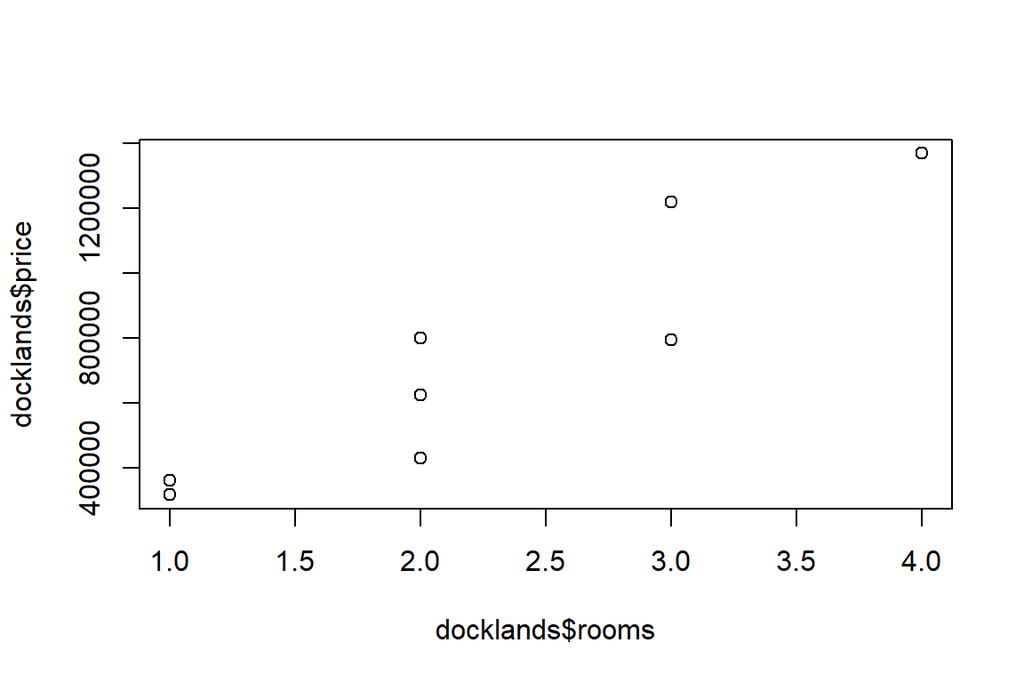

```r
options(scipen = 1000000)
docklands <- melbourne_housing %>%
  filter(suburb == "Docklands") %>%
  filter(!is.na(price))
plot(docklands$rooms, docklands$price)
```

## ggplot and grammar of graphics

- This is where `ggplot2` was written, as a way to define grammar of graphics
- A consistent structure to build a plot
- One system, learn one time, reapply many times for different graphics
- Break down plotting into different layers
- Every ggplot consists of 3 major components
  - The data (For example the melbourne_housing data frame)
  - The geom (Say a scatter plot)
  - The aesthetic mappings (what the x axis should be, what the y axis should be)

## Our first ggplot

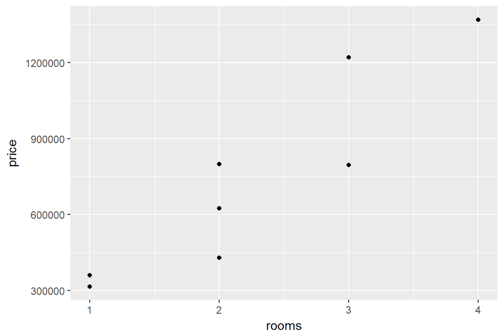

```r
ggplot(docklands) +
  geom_point(aes(x = rooms,
                 y = price))
```

## Adding colour

- Lets say we want to distinguish houses, townhouses and units by different colours

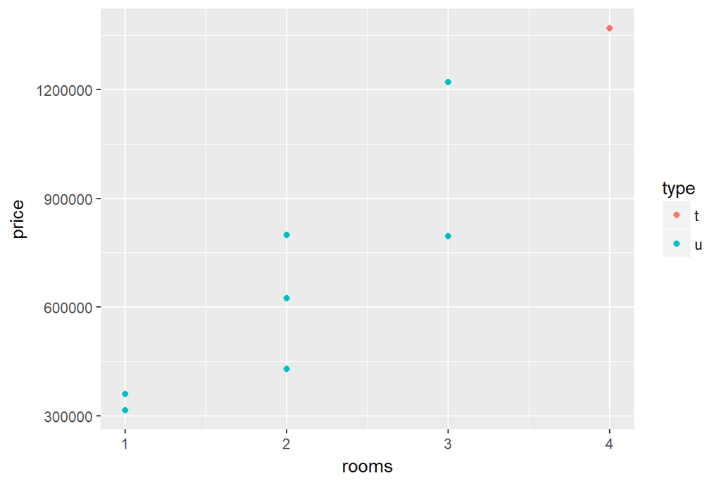

```r
ggplot(docklands) +
  geom_point(aes(x = rooms, y = price, colour = type))
```

## Adding nice labels

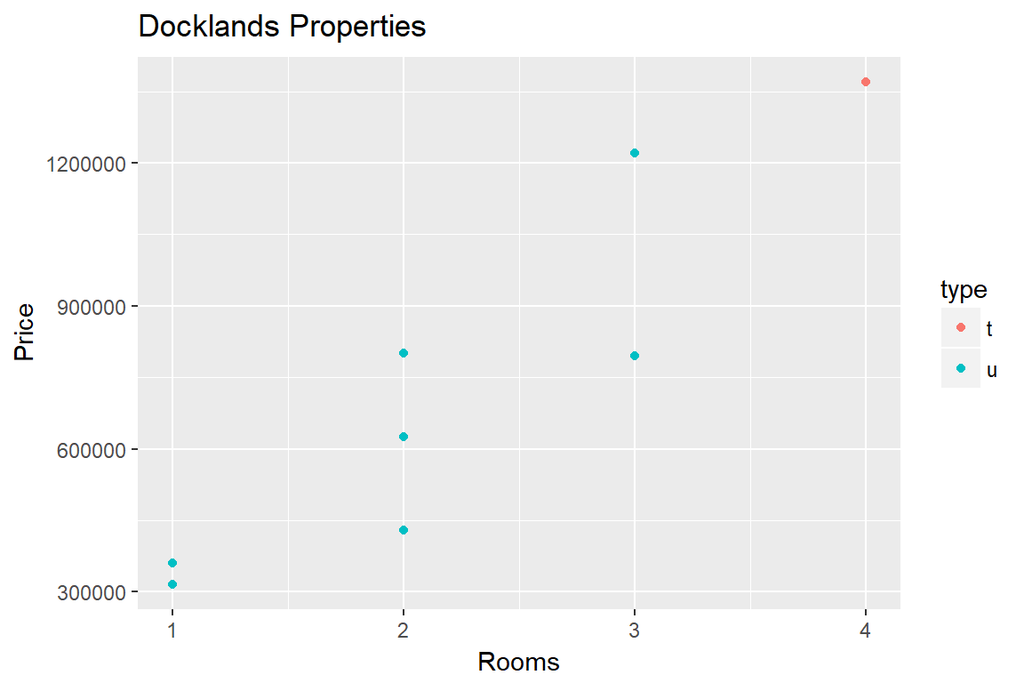

```r
ggplot(docklands) +
  geom_point(aes(x = rooms, y = price, colour = type)) +
  labs(x = "Rooms", y = "Price", title = "Docklands Properties")
```

## Other types of geoms

- Now that you’ve seen how easy it is to create ggplots, lets have a look at some other geoms commonly used
- Histograms: To study the underlying distribution of a variable
- Boxplot: Alternative way to study distribution, but with median, IQR etc
- Bar plot: To study how categorical variables are represented
- Line plot: To study trends of a variable

## Histograms

- Lets have a look at the distribution of property prices in the Melbourne council region
- We can create the data frame to send to the plot by first running the required `dplyr` code and then piping that into the `ggplot` function

```r
melbourne_housing %>%
  inner_join(suburb_data, by = "suburb") %>%
  filter(council_area == "Melbourne City Council") %>%
  ggplot() +
  geom_histogram(aes(x = price)) +
  labs(x = "Price",
       y = "Number of properties")
```

## Histograms

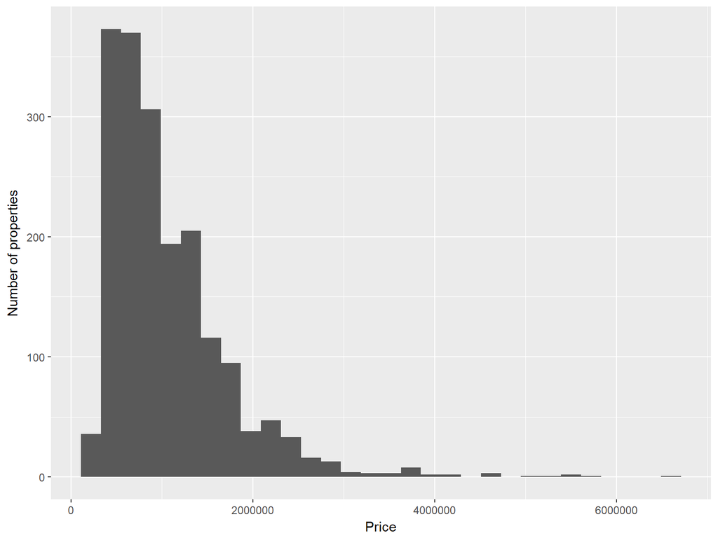

## Boxplot

- Lets plot the same thing, but lets have a look at the distribution from a different angle
- Also lets split it up by the suburbs in the region to see if there’s any difference

```r
melbourne_housing %>%
  inner_join(suburb_data, by = "suburb") %>%
  filter(council_area == "Melbourne City Council") %>%
  ggplot() +
  geom_boxplot(aes(x = suburb, y = price, fill = suburb)) +
  labs(x = "Suburb",
       y = "Price",
       title = "Price distribution of Melbourne City Council")
```

## Boxplot

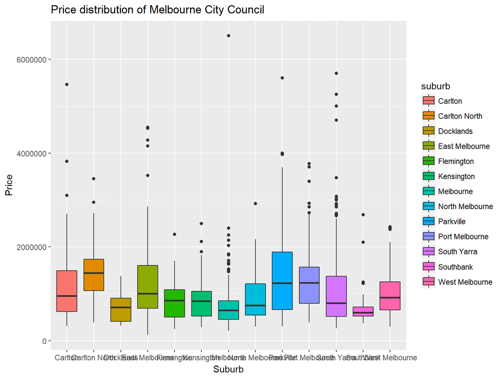

## Bar Plot

- Bar plots require your data to be in narrow form as opposed to wide form
- Remember to use `spread` & `gather` as necessary if you need to convert the data
- Bar plots can be very intelligent and customisable, but today we will learn the most basic form `stat = "identity"`. This just means that the y axis value you supply should be used as it is, without any transformations

```r
melbourne_housing %>%
  inner_join(suburb_data, by = "suburb") %>%
  filter(council_area == "Melbourne City Council") %>%
  group_by(suburb) %>%
  summarise(number_of_properties = n()) %>%
  ggplot() +
  geom_bar(aes(x = suburb, y = number_of_properties, fill = suburb),
           stat = "identity") +
  labs(x = "Suburb", y = "Number of Properties",
       title = "Properties sold in Melbourne City Council")
```

## Bar Plot

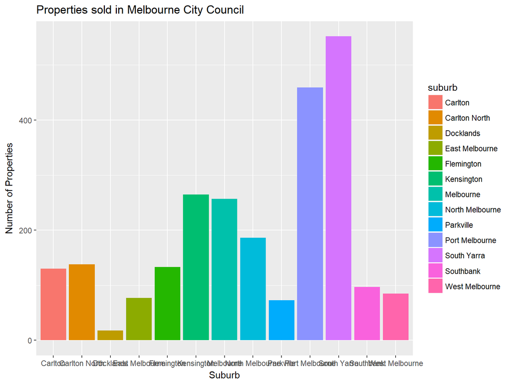

## Line Plot

- Line plots are really useful if you want to track the flow of a metric along a number line
- Typically these are used to display time based trends
- Structure very similar to bar plot but instead you use `geom_line`
- Different lines can be coloured but `ggplot` also requires each line to be its own `group`

```r
melbourne_housing %>%
  inner_join(suburb_data, by = "suburb") %>%
  filter(council_area == "Melbourne City Council") %>%
  mutate(dt = lubridate::dmy(dt)) %>%
  mutate(yr = lubridate::floor_date(dt, unit = "year")) %>%
  group_by(suburb, yr) %>%
  summarise(median_house_price = median(price, na.rm = TRUE)) %>%
  ggplot() +
  geom_line(aes(x = yr,
                y = median_house_price,
                group = suburb,
                colour = suburb)) +
  labs(x = "Year", y = "Median Price", title = "Price Trend")
```

## Line Plot

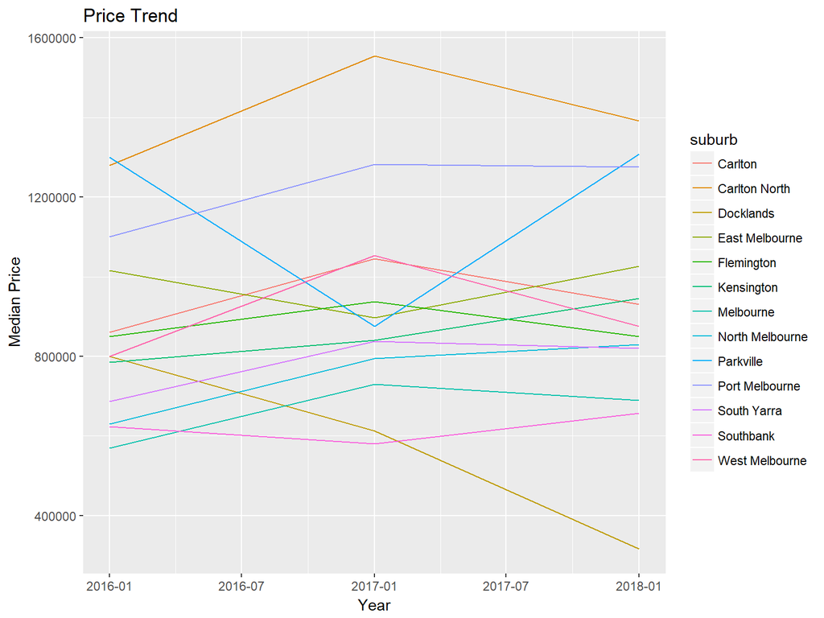

## Customising your ggplots

- Now that we know how to make basic charts in ggplot we can explore the power of customisation
- How to change colours
- Zooming out and in
- Manipulating shapes and sizes of scatter plot
- Transformation of scales
- Facets

## Colours

- R gives you a bunch of default colour palettes to choose from
- This [cheatsheet](https://www.nceas.ucsb.edu/~frazier/RSpatialGuides/colorPaletteCheatsheet.pdf) has lot of details but lets focus on the bottom left of the last page
- Lets build a simiar box plot to what we built earlier, but for Bayside City Council
- The only difference is, we have specified a `scale_fill_brewer`
- If we are changing the colour for a colour element it will be `scale_colour_brewer`

```r
melbourne_housing %>%
  inner_join(suburb_data, by = "suburb") %>%
  filter(council_area == "Bayside City Council") %>%
  ggplot() +
  geom_boxplot(aes(x = suburb, y = price, fill = suburb)) +
  labs(x = "Suburb",
       y = "Price",
       title = "Price distribution of Bayside City Council") +
  scale_fill_brewer(palette = "Paired")
```

## Colours

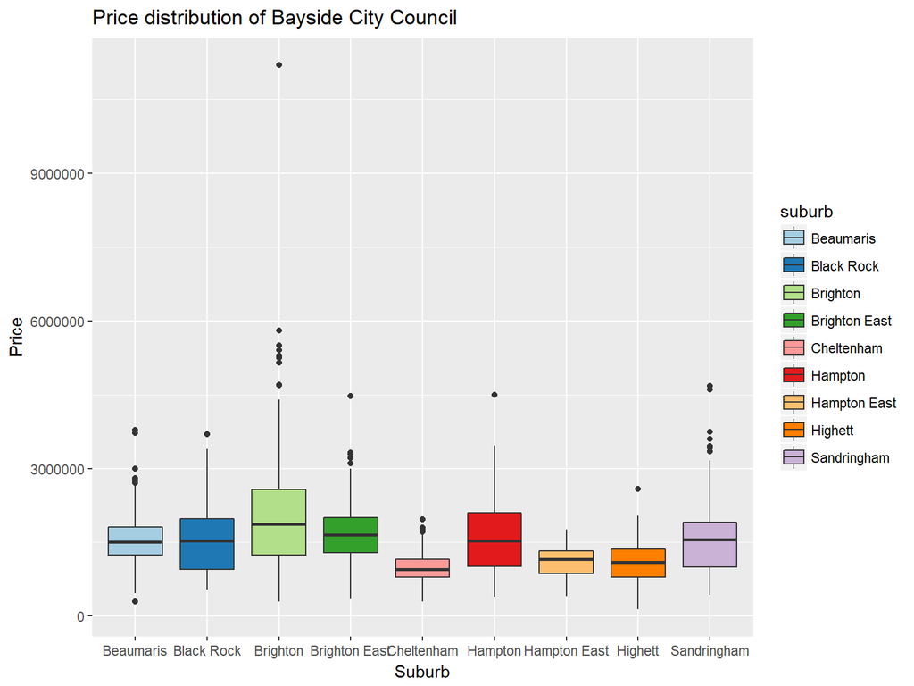

## Zooming

- In the chart we just created, one super expensive house in Brighton really spoiled the scale for everything else
- While we were able to see that Cheltenham, Hampton East and Highett were clearly lower value suburbs than the others, we couldn’t see subtle differences
- ggplot gives you a `coord_cartesian` function to let you zoom in on specific sections of your plot

```r
melbourne_housing %>%
  inner_join(suburb_data, by = "suburb") %>%
  filter(council_area == "Bayside City Council") %>%
  ggplot() +
  geom_boxplot(aes(x = suburb, y = price, fill = suburb)) +
  labs(x = "Suburb",
       y = "Price",
       title = "Price distribution of Bayside City Council") +
  scale_fill_brewer(palette = "Paired") +
  coord_cartesian(ylim = c(0, 3000000))
```

## Zooming

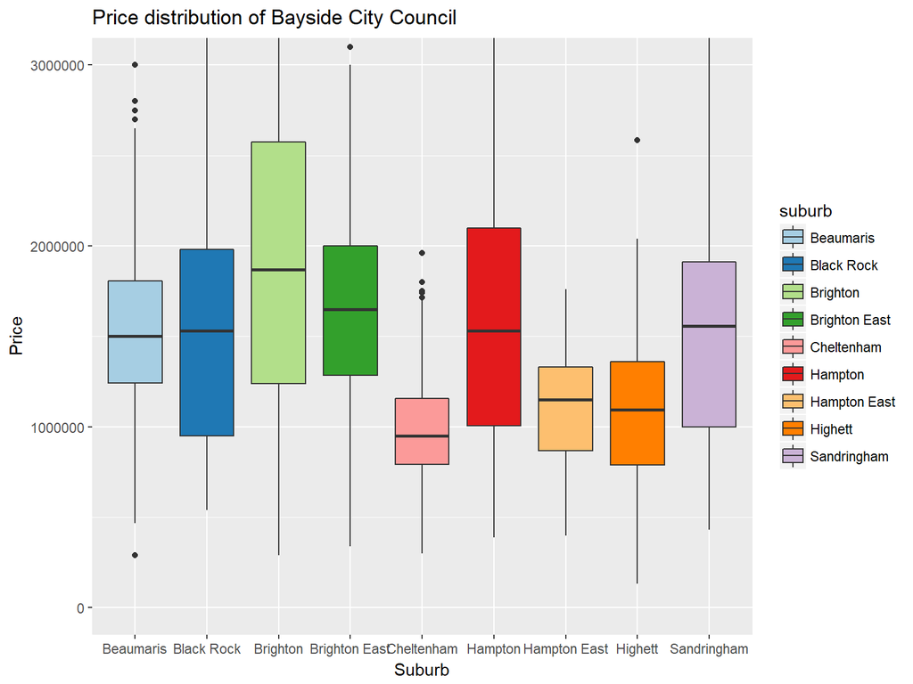

## Shapes, sizes, alpha

- Lets build a scatter plot that visualises distance from city and median property price for 3 metro regions
- A simple scatter plot will look like this (we have learnt to colour, so we will add colour)

```r
melbourne_housing %>%
  inner_join(suburb_data, by = "suburb") %>%
  filter(region_name %in% c("Southern Metropolitan",
                            "South-Eastern Metropolitan",
                            "Eastern Metropolitan")) %>%
  group_by(region_name, council_area, suburb, distance_from_city) %>%
  summarise(median_property_price = median(price, na.rm = TRUE)) %>%
  ggplot() +
  geom_point(aes(x = distance_from_city,
                 y = median_property_price,
                 colour = region_name)) +
  labs(x = "Distance From City",
       y = "Median Property Price",
       tilte = "Relationship between distance and price") +
  scale_color_manual(values = c("blue","red","green"))
```

## Shapes, sizes and alpha

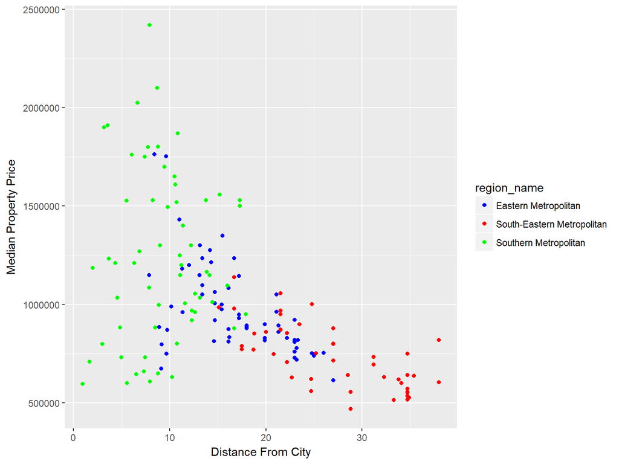

## Shapes

- Instead of distinguishing the region by colour, ggplot also allows you to distinguish by other options
- Lets try different shapes for our scatter plot points
- Simlar code, except instead of `colour` you will specify `shape`

```r
melbourne_housing %>%
  inner_join(suburb_data, by = "suburb") %>%
  filter(region_name %in% c("Southern Metropolitan",
                            "South-Eastern Metropolitan",
                            "Eastern Metropolitan")) %>%
  group_by(region_name, council_area, suburb, distance_from_city) %>%
  summarise(median_property_price = median(price, na.rm = TRUE)) %>%
  ggplot() +
  geom_point(aes(x = distance_from_city,
                 y = median_property_price,
                 shape = region_name)) +
  labs(x = "Distance From City",
       y = "Median Property Price",
       tilte = "Relationship between distance and price")
```

## Shapes

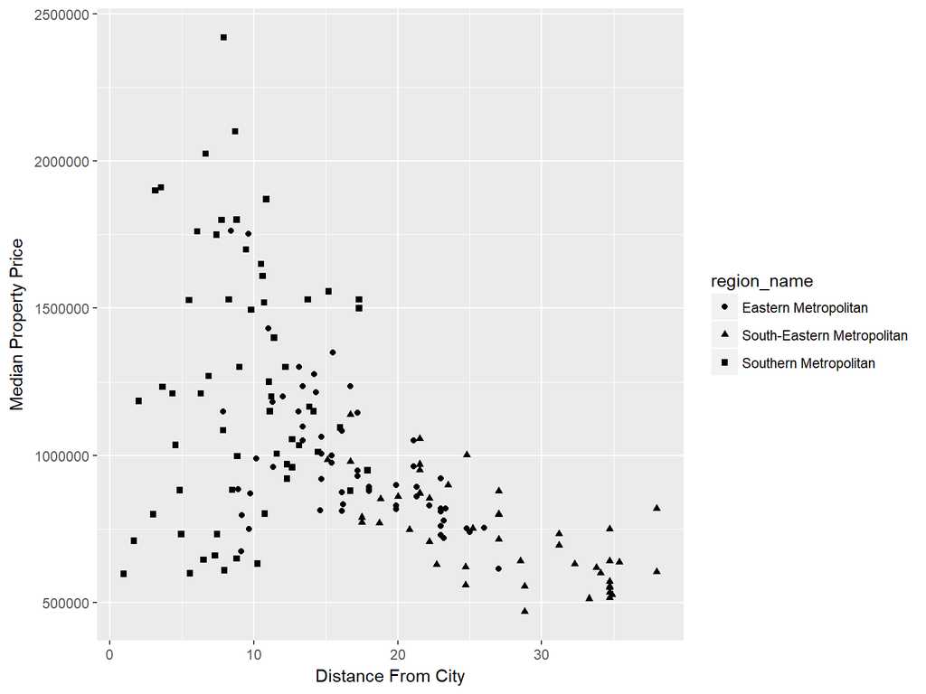

## Shapes

```r
melbourne_housing %>%
  inner_join(suburb_data, by = "suburb") %>%
  filter(region_name %in% c("Southern Metropolitan",
                            "South-Eastern Metropolitan",
                            "Eastern Metropolitan")) %>%
  group_by(region_name, council_area, suburb, distance_from_city) %>%
  summarise(median_property_price = median(price, na.rm = TRUE)) %>%
  ggplot() +
  geom_point(aes(x = distance_from_city,
                 y = median_property_price,
                 shape = council_area,
                 colour = region_name)) +
  labs(x = "Distance From City",
       y = "Median Property Price",
       tilte = "Relationship between distance and price") +
  scale_colour_brewer(palette = "Dark2") +
  scale_shape_manual(values = c(1:17))
```

## Shapes

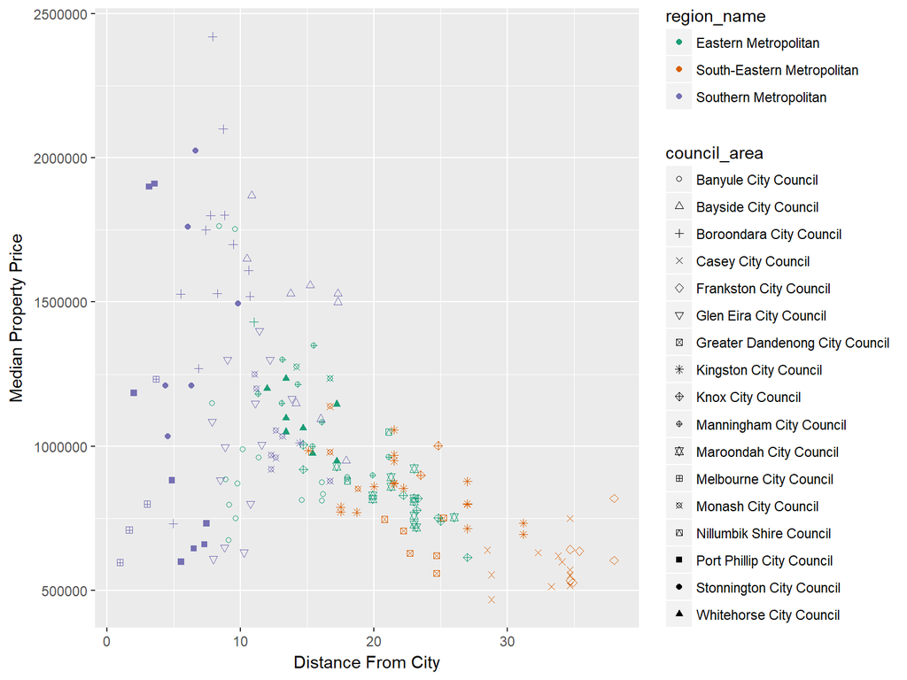

## Sizes

- ggplot also allows you to customise the size of your points
- Typically if you want to donate a third value in a chart to show proportion we can alter the size of the point according to a value
- Same example, but say we want to investigate whether a suburb like Brighton, does it just have a few high valued properties or does it score high on volume as well

```r
melbourne_housing %>%
  inner_join(suburb_data, by = "suburb") %>%
  filter(council_area == "Bayside City Council") %>%
  group_by(council_area, suburb, distance_from_city) %>%
  summarise(median_property_price = median(price, na.rm = TRUE),
            number_of_sales = n()) %>%
  ggplot() +
  geom_point(aes(x = distance_from_city,
                 y = median_property_price,
                 colour = suburb,
                 size = number_of_sales)) +
  labs(x = "Distance From City",
       y = "Median Property Price",
       tilte = "Relationship between distance and price") +
  scale_colour_brewer(palette = "Spectral")
```

## Sizes

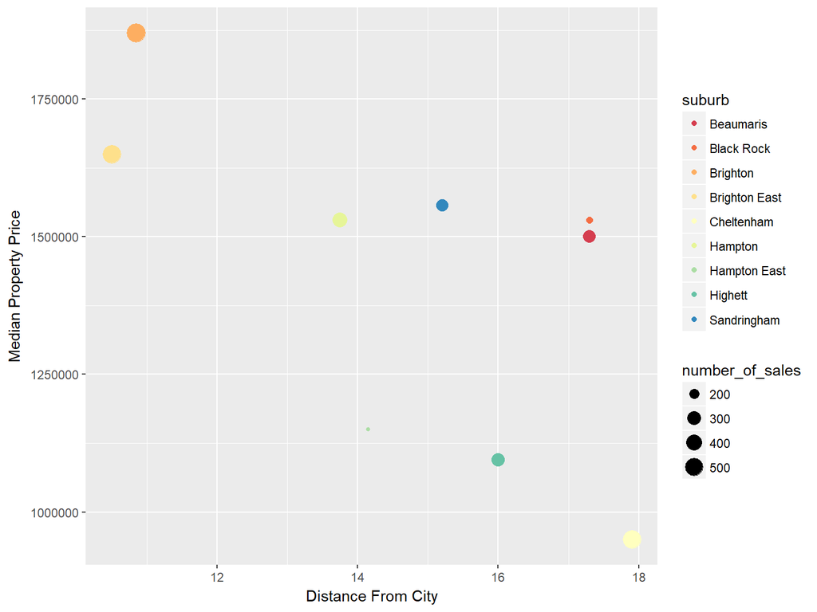

## Alpha

- ggplot also allows you to customise the opacity of your points
- Can be used as an alternative to size
- Lets have a look at the same chart but with alpha instead of size
- alpha can be set as a value between 0 and 1 where 0.9 is closer to opaque and 0.1 is closer to transparent

```r
melbourne_housing %>%
  inner_join(suburb_data, by = "suburb") %>%
  filter(council_area == "Bayside City Council") %>%
  group_by(council_area, suburb, distance_from_city) %>%
  summarise(median_property_price = median(price, na.rm = TRUE),
            number_of_sales = n()) %>%
  ggplot() +
  geom_point(aes(x = distance_from_city,
                 y = median_property_price,
                 colour = suburb,
                 size = 4,
                 alpha = number_of_sales)) +
  labs(x = "Distance From City",
       y = "Median Property Price",
       tilte = "Relationship between distance and price") +
  scale_colour_brewer(palette = "Spectral")
```

## Alpha

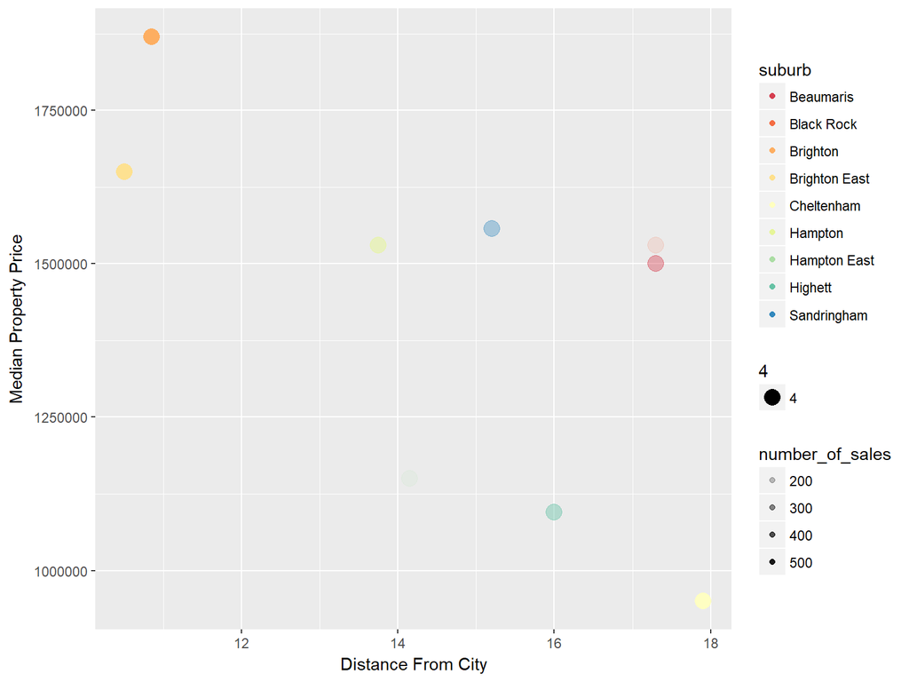

## Facets

- Until now we have learnt how to change several aesthetics, use several geoms and create some great graphs
- Sometimes we may want to overlay different panels of graphs together showing something very similar
- ggplot allows you to do this over facets
- Lets try and plot how property sales vary between houses, townhouses and units in the Monash City Council

```r
melbourne_housing %>%
  inner_join(suburb_data, by = "suburb") %>%
  filter(council_area == "Monash City Council") %>%
  group_by(suburb, type) %>%
  summarise(median_property_value = median(price, na.rm = TRUE)) %>%
  ggplot() +
  geom_bar(aes(x = suburb, y = median_property_value, fill = suburb),
           stat = "identity") +
  facet_wrap(~ type, nrow = 3, ncol = 1) +
  labs(x = "Suburb", y = "Median Property Value")
```

## Facets

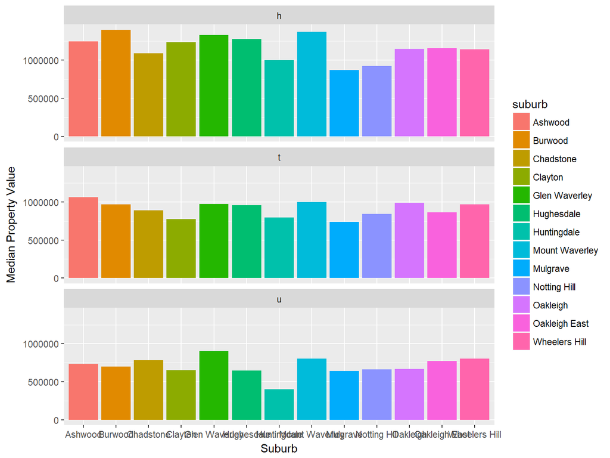

## Themes

- ggplot offers a lot of customisability on plot themes
- There are several inbuilt theme presets like `theme_minimal`, `theme_classic` etc
- You can also create your own theme using the `theme` function if you want to
- Replicating the same facet plot from the previous slide

```r
melbourne_housing %>%
  inner_join(suburb_data, by = "suburb") %>%
  filter(council_area == "Monash City Council") %>%
  group_by(suburb, type) %>%
  summarise(median_property_value = median(price, na.rm = TRUE)) %>%
  ggplot() +
  geom_bar(aes(x = suburb, y = median_property_value, fill = suburb),
           stat = "identity") +
  facet_wrap(~ type, nrow = 3, ncol = 1) +
  labs(x = "Suburb", y = "Median Property Value") +
  theme_minimal()
```

## Themes

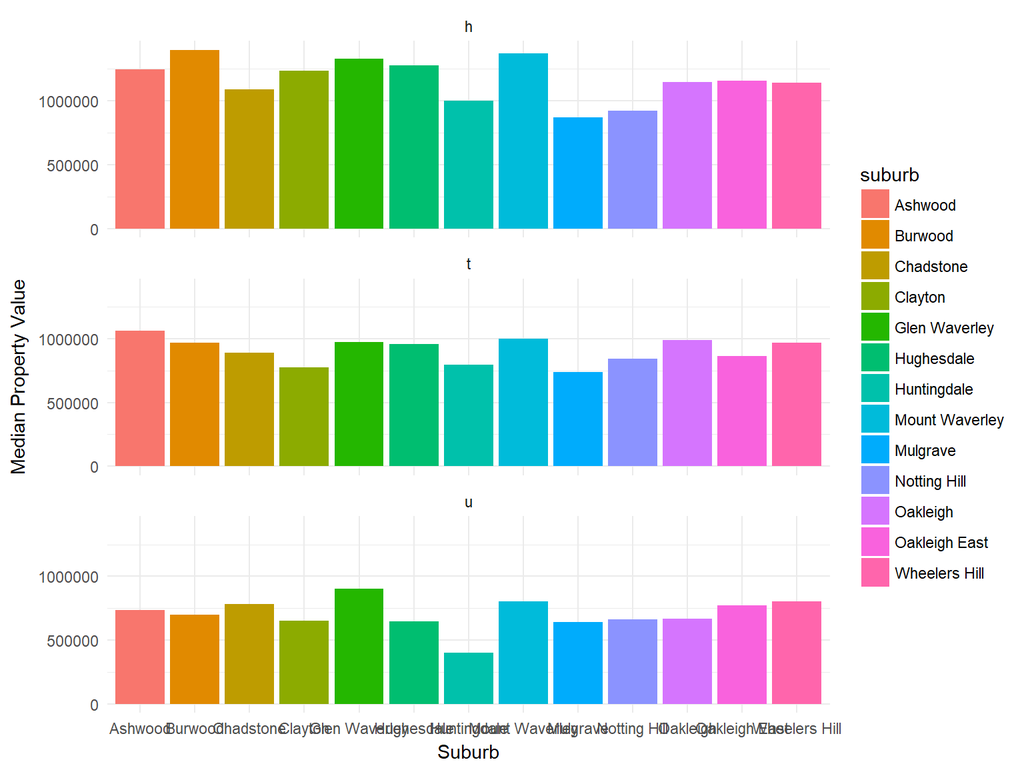

## Practice Question 1

- I’d like to plot a monthly trend line of how median property prices are tracking for each region
- Hint: Use `lubridate::dmy(dt)` to convert `dt` to a date format and use `lubridate::floor_date(dt, unit = "month")` to extract the month
- Hint: Use `geom_line()` with x axis as the month, y axis as median price, and group and colour as `region_name` from `suburb_data`
- Expected output is

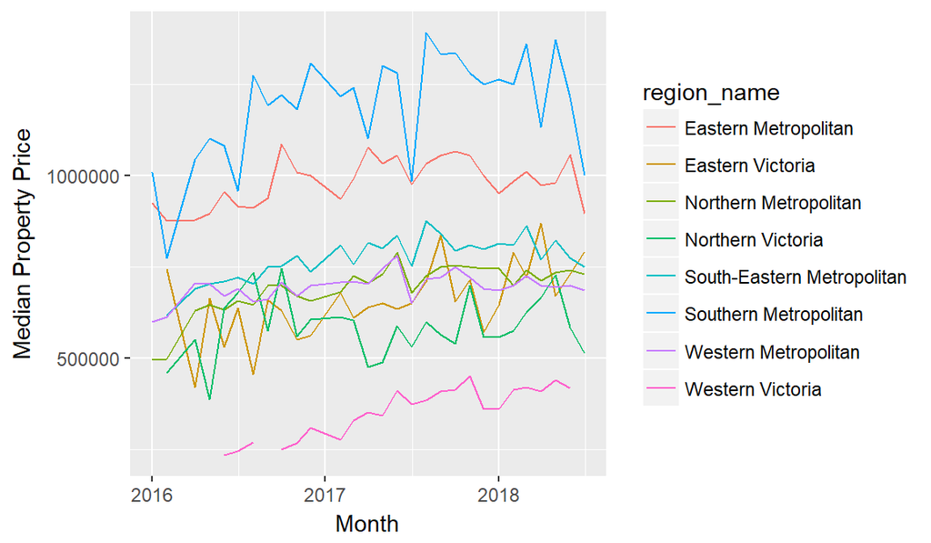

## Practice Question 1 - Solution

```r
melbourne_housing %>%
  inner_join(suburb_data, by = "suburb") %>%
  mutate(dt = lubridate::dmy(dt)) %>%
  mutate(mth = lubridate::floor_date(dt, unit = "month")) %>%
  group_by(region_name, mth) %>%
  summarise(median_property_price = median(price, na.rm=TRUE)) %>%
  ggplot() +
  geom_line(aes(x = mth, y = median_property_price,
                group = region_name, colour = region_name)) +
  labs(x = "Month", y = "Median Property Price",
       tilte = "Region wise property prices")
```

## Practice Question 2

- I’m looking at properties in Ringwood, Ringwood North and Ringwood East and I want to get an idea on the distribution of prices and visualise how much an extra room costs
- Hint: Use a boxplot to showcase the distribution and Use facets to compare at all 3 suburbs at once
- Hint: Convert rooms to character using `as.charcater(rooms)` otherwise ggplot thinks rooms is an integer continous variable
- Expected output is

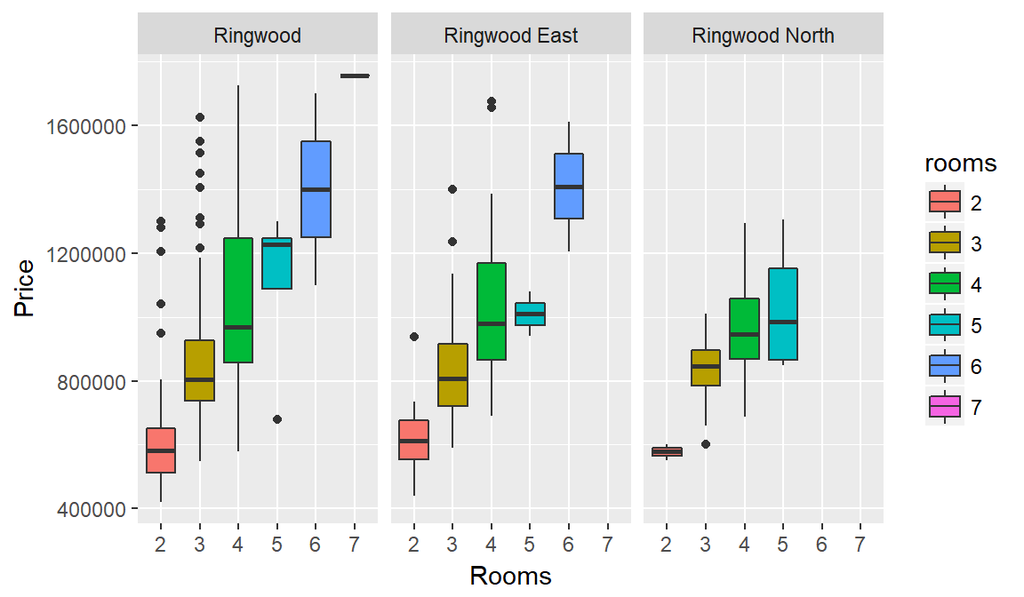

## Practice Question 2 - Solution

```r
melbourne_housing %>%
  filter(suburb %in% c("Ringwood", "Ringwood North", "Ringwood East")) %>%
  mutate(rooms = as.character(rooms)) %>%
  ggplot() +
  geom_boxplot(aes(x = rooms, y = price, group = rooms, fill = rooms)) +
  facet_wrap(~ suburb, nrow = 1, ncol = 3) +
  labs(x = "Rooms", y = "Price")
```

## Practice Question 3

- I want to see what is the break up of property sales in the Port Phillip City Council by suburb, and I’m keen on knowing what percentage of all sales is units, townhouses and houses for each suburb
- Hint: Use `summarise` and `mutate` to create percentage of total metric
- Hint: Use `geom_bar` to create a stacked bar chart. Once you create your chart try adding `position = position_dodge()` to the `geom_bar` part of the code and see what changes
- Expected output is

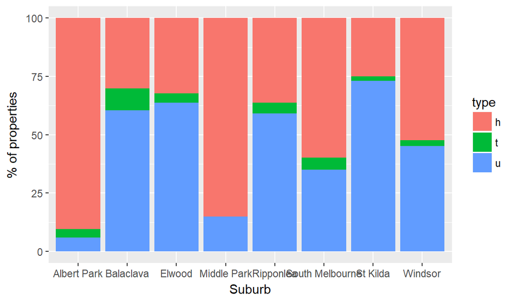

## Practice Question 3 - Solution

```r
melbourne_housing %>%
  inner_join(suburb_data, by="suburb") %>%
  filter(council_area == "Port Phillip City Council") %>%
  group_by(suburb, type) %>%
  summarise(number_of_properties = n()) %>%
  mutate(perc_of_total = number_of_properties/sum(number_of_properties)*100) %>%
  ggplot() +
  geom_bar(aes(x = suburb, y = perc_of_total, fill = type),
           stat = "identity") +
  labs(x = "Suburb", y = "% of properties")
```

# Rmarkdown and related tools

## Why Rmarkdown?

- Rmarkdown is a system where you can put everything you learnt today together to produce reproducible anlaysis
- Rmarkdown lets you combine code, results, and commentary into one place
- Rmarkdown lets you use multiple languages (not just R but Python and SQL too) together
- Rmarkdown lets you create multiple output formats - PDFs, HTMLs, Word Docs, Powerpoint (yes this one is built in Rmarkdown!), books, dashboards, blogs, shiny applications etc
- Rmarkdown also lets you use the notebook feature - a popular data science tool
- Built using markdown, which is the easiest language ever created

## What we will learn today

- Creating simple Rmarkdown documents
- Using Rmarkdown notebooks
- Flexdashboard
- Very simple introduction to shiny

[figure not shown]

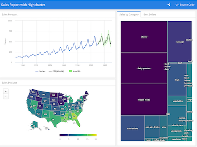

## Our very first Rmarkdown

- First we must install the `rmarkdown` package

```r
install.packages("rmarkdown")
```

- Now open a .Rmd document from File > New File > R Markdown and choose a title like `My First RMarkdown`
- You will find some example code in your newly opened file
- There are 4 different sections
  - YAML header
  - Code Chunks (in grey)
  - Headers after #
  - Plain text

## YAML Header

- The section right at the top between the `---` lines is called the YAML header
- In the YAML header we specify attributes about the document like
  - Title
  - Author
  - Output style - Rmarkdown document, slides, dashboard etc
  - Other features - default image size, themes etc
- For our simple example lets just set the title and leave the output as a HTML document

[figure not shown]

## Code Chunks

- The section in the grey bit is called code chunks. You can have as many as you want.
- When you render (run) the Rmd file the code inside the chunk will be run and results will be embedded in the report
- Lets try an example where we play with our `melbourne_housing` dataset and the last ggplot we created, but instead of the plot lets just print the data frame
- Keep in mind that when you run a rmarkdown file, it is a new R session so we need the code for loading our data files. Insert this into your code chunk and hit the `knit` button

```r
library(tidyverse)
library(lubridate)

melbourne_housing <- read_csv("C:/Workspace/r-learning/data/processed/melbourne_housing_market.csv")
suburb_data <- read_csv("C:/Workspace/r-learning/data/processed/suburb_data.csv")

melbourne_housing %>%
  inner_join(suburb_data, by="suburb") %>%
  filter(council_area == "Port Phillip City Council") %>%
  group_by(suburb, type) %>%
  summarise(number_of_properties = n()) %>%
  mutate(perc_of_total = number_of_properties/sum(number_of_properties)*100)
```

## Code Chunks

- For our second code chunk lets paste the entire code that prints out the ggplot as well

```r
melbourne_housing %>%
  inner_join(suburb_data, by="suburb") %>%
  filter(council_area == "Port Phillip City Council") %>%
  group_by(suburb, type) %>%
  summarise(number_of_properties = n()) %>%
  mutate(perc_of_total = number_of_properties/sum(number_of_properties)*100) %>%
  ggplot() +
  geom_bar(aes(x = suburb, y = perc_of_total, fill = type),
           stat = "identity") +
  labs(x = "Suburb", y = "% of properties")
```

- Code chunk can be named if you wish
- Code chunks can also take several options in the format of `{r, echo=FALSE}`
  - echo - To print the code chunk or not (prints only the output)
  - eval - To evaluate the code chunk or not (prints only the code)
  - warning - To print warnings or not
  - message - To print other R console messages or not
  - fig.width and fig.height - To specify sizes for charts

## Headers and Text

- Rest of what goes in is just pure markdown syntax
- Plain text appears as plain text
- You can specify headers by using the `#` for level 1 header (big) `##` for level 2 header (slightly smaller) and so on
- You can insert bullet points by adding `-` at the start of a line
- You can bold text by wrapping it within starts like `**boldtext**`
- You can display text it italics similarly like `*italics*`
- You can also write Maths equations, put in links, use any standard HTML formatting etc if you want to
- Try a few different things in your markdown by writing text, putting headers, making things bold etc

## Notebooks

- Notebooks are a relatively new feature in R
- It takes after a popular concept in Python called Jupyter Notebooks and evolved it for R
- If you notice in your Rmd file, the code section has a green coloured run button
- Notebook allows you to run your code chunks and place the output immediately below so that you can test and iterate quickly
- It is an excellent tool for exploratory data anlaysis as you can just keep trying stuff and seeing results immediately
- It is also a great tool for a data science team if you want to share code and analysis, especially with version controlling
- Notebooks create a .nb.html file every time you save your .RMd file where the results can be seen without having to knit the whole document

## Flexdashboard

- Flexdashboard is a Rmarkdown based system that allows you to group several elements like graphs, tables etc into a dashboard
- Flexdashboard gives you several options to customise layout but makes it easy using markdown as opposed to web styling like CSS
- To get started we must install the package and then FIle > New File > Rmarkdown > From Template > Flexdashboard

```r
install.packages("flexdashboard")
```

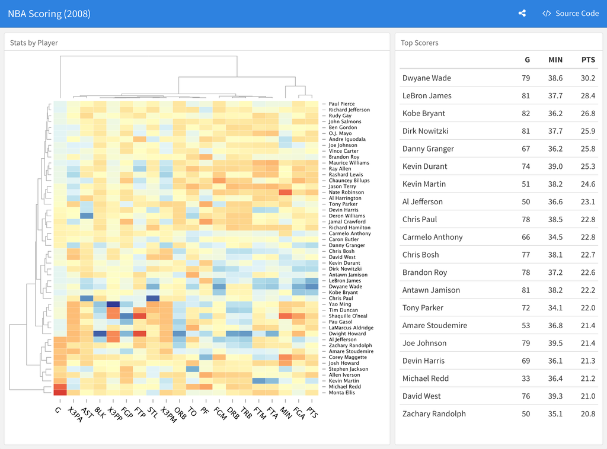

## Flexdashboard

- Just like regular markdown there is a YAML header section
- There are code chunks where you write code to output charts or tables or anything else
- Each of the `-----` lines denote a new column (or row if the YAML header is specified as Row)
- Each of the `###` adds a new box where you can use the code chunk beneath it to place your code for your charts or tables
- Lets try placing the same code from our previous Rmarkdown file into these boxes and see what happens when we knit the document
- Flexdashboards knit and create .html files which anyone use easily with just a browser
- Flexdashboards also allow for interactivity using Shiny

## Shiny

- Shiny is a web application development framework
- Built entirely in R so that you don’t need to know the 1000 web app frameworks around today
- You can build standalone shiny apps
- Or you can add shiny elements to dashboards, Rmarkdown etc
- Today we will build a very simple flexdashboard with shiny elements to give ourselves an idea of what shiny is capable of

## Very simple shiny app

- To make a regular flexdashboard a shiny app we must change a few things
- In the YAML section let we have to add a line which will change the Knit button to Run document

```r
---
title: "Untitled"
output:
  flexdashboard::flex_dashboard:
    orientation: columns
    vertical_layout: fill
runtime: shiny
---
```

## Very simple shiny app

- Adding `{.sidebar}` to the first column of the dashboard will let R know that that column will be where the shiny input controls are
- Now lets add this piece of code to the set up chunk defined above to load the data files (Remember the slide about every Rmd file being a new session)

```r
library(tidyverse)
library(lubridate)
library(shiny)

melbourne_housing <- read_csv("C:/Workspace/r-learning/data/processed/melbourne_housing_market.csv")
suburb_data <- read_csv("C:/Workspace/r-learning/data/processed/suburb_data.csv")
```

```r
selectInput(inputId = "council_area_choice",
            label = "Select a Council Area",
            choices = suburb_data %>% pull(council_area),
            selected = "Port Phillip City Council")
```

## Very simple shiny app

- The boxes in the second column can have the same two commands, for displaying the table and displaying the chart
- But instead of hardcoding the value as Port Phillip City Council, we will say `input$council_area_choice` which will dynamically pass what the user picked and refresh the chart and table accordingly
- One small change is, we need to put our code for the table and chart inside shiny’s `render` family of functions like `renderTable` and `renderPlot`

```r
renderTable({
  melbourne_housing %>%
  inner_join(suburb_data, by="suburb") %>%
  filter(council_area == input$council_area_choice) %>%
  group_by(suburb, type) %>%
  summarise(number_of_properties = n()) %>%
  mutate(perc_of_total = number_of_properties/sum(number_of_properties)*100)
})
```

- Shiny allows for many such inputs like slider, date, text, radio button etc and they can all be passed as dynamic parmeters that change results making a dynamic report

# Conclusion

## What we have learnt

- How to get started in R
- Analysing and data wrangling using dplyr
- Visualising data using ggplot
- Putting everything together using Rmarkdown tools
- That is a solid skill set to possess to do data analysis: Well done!

## Next Steps

- Lots of practice to get familiar with tools
- Advanced concepts and packages
  - Purrr for functional programming styles
  - More detailed shiny apps
  - Tidy evaluation for more dynamic code and less repetiion
- Predictive Modelling (and lots of practice)
- Keep trying things and learning things!

## Thank you

- Thanks for spending your time today and being so patient learning
- If you have any questions please don’t hesitate to ask
- If you have questions after today while putting this into practice, please reach out at kaushiklakshman@gmail.com
- Thank you!